# Risk Factor Analysis

## Outcome Variable

**Outcome Variable:** ever_co

## Predictor Variables

**Intervention Variable:** nhh

**Adjustment Set:**

unadjusted

## Stratifying Variables

The analysis was stratified on these variable(s):

- agecat
- studyid
- country

## Data Summary

| agecat | studyid | country | nhh | ever_co | n_cell | n |
| --- | --- | --- | --- | --- | --- | --- |
| 0-24 months | IRC | INDIA | 3 or less | 0 | 51 | 410 |
| 0-24 months | IRC | INDIA | 3 or less | 1 | 7 | 410 |
| 0-24 months | IRC | INDIA | 4-5 | 0 | 129 | 410 |
| 0-24 months | IRC | INDIA | 4-5 | 1 | 29 | 410 |
| 0-24 months | IRC | INDIA | 6-7 | 0 | 89 | 410 |
| 0-24 months | IRC | INDIA | 6-7 | 1 | 18 | 410 |
| 0-24 months | IRC | INDIA | 8+ | 0 | 65 | 410 |
| 0-24 months | IRC | INDIA | 8+ | 1 | 22 | 410 |
| 0-24 months | LCNI-5 | MALAWI | 3 or less | 0 | 214 | 817 |
| 0-24 months | LCNI-5 | MALAWI | 3 or less | 1 | 11 | 817 |
| 0-24 months | LCNI-5 | MALAWI | 4-5 | 0 | 323 | 817 |
| 0-24 months | LCNI-5 | MALAWI | 4-5 | 1 | 17 | 817 |
| 0-24 months | LCNI-5 | MALAWI | 6-7 | 0 | 176 | 817 |
| 0-24 months | LCNI-5 | MALAWI | 6-7 | 1 | 6 | 817 |
| 0-24 months | LCNI-5 | MALAWI | 8+ | 0 | 62 | 817 |
| 0-24 months | LCNI-5 | MALAWI | 8+ | 1 | 8 | 817 |
| 0-24 months | NIH-Birth | BANGLADESH | 3 or less | 0 | 93 | 624 |
| 0-24 months | NIH-Birth | BANGLADESH | 3 or less | 1 | 22 | 624 |
| 0-24 months | NIH-Birth | BANGLADESH | 4-5 | 0 | 196 | 624 |
| 0-24 months | NIH-Birth | BANGLADESH | 4-5 | 1 | 67 | 624 |
| 0-24 months | NIH-Birth | BANGLADESH | 6-7 | 0 | 114 | 624 |
| 0-24 months | NIH-Birth | BANGLADESH | 6-7 | 1 | 27 | 624 |
| 0-24 months | NIH-Birth | BANGLADESH | 8+ | 0 | 84 | 624 |
| 0-24 months | NIH-Birth | BANGLADESH | 8+ | 1 | 21 | 624 |
| 0-24 months | NIH-Crypto | BANGLADESH | 3 or less | 0 | 105 | 758 |
| 0-24 months | NIH-Crypto | BANGLADESH | 3 or less | 1 | 9 | 758 |
| 0-24 months | NIH-Crypto | BANGLADESH | 4-5 | 0 | 304 | 758 |
| 0-24 months | NIH-Crypto | BANGLADESH | 4-5 | 1 | 38 | 758 |
| 0-24 months | NIH-Crypto | BANGLADESH | 6-7 | 0 | 163 | 758 |
| 0-24 months | NIH-Crypto | BANGLADESH | 6-7 | 1 | 15 | 758 |

[output cut: 114 more lines]

The following strata were considered:

- agecat: 0-24 months, studyid: IRC, country: INDIA
- agecat: 0-24 months, studyid: LCNI-5, country: MALAWI
- agecat: 0-24 months, studyid: NIH-Birth, country: BANGLADESH
- agecat: 0-24 months, studyid: NIH-Crypto, country: BANGLADESH
- agecat: 0-24 months, studyid: PROVIDE, country: BANGLADESH
- agecat: 0-24 months, studyid: SAS-FoodSuppl, country: INDIA
- agecat: 0-6 months, studyid: IRC, country: INDIA
- agecat: 0-6 months, studyid: LCNI-5, country: MALAWI
- agecat: 0-6 months, studyid: NIH-Birth, country: BANGLADESH
- agecat: 0-6 months, studyid: NIH-Crypto, country: BANGLADESH
- agecat: 0-6 months, studyid: PROVIDE, country: BANGLADESH
- agecat: 0-6 months, studyid: SAS-FoodSuppl, country: INDIA
- agecat: 6-24 months, studyid: IRC, country: INDIA
- agecat: 6-24 months, studyid: LCNI-5, country: MALAWI
- agecat: 6-24 months, studyid: NIH-Birth, country: BANGLADESH
- agecat: 6-24 months, studyid: NIH-Crypto, country: BANGLADESH
- agecat: 6-24 months, studyid: PROVIDE, country: BANGLADESH
- agecat: 6-24 months, studyid: SAS-FoodSuppl, country: INDIA

### Dropped Strata

Some strata were dropped due to rare outcomes:

- agecat: 0-6 months, studyid: IRC, country: INDIA
- agecat: 0-6 months, studyid: LCNI-5, country: MALAWI
- agecat: 0-6 months, studyid: NIH-Crypto, country: BANGLADESH
- agecat: 0-6 months, studyid: PROVIDE, country: BANGLADESH
- agecat: 0-6 months, studyid: SAS-FoodSuppl, country: INDIA

## Methods Detail

We’re interested in the causal parameters $E[Y_a]$ for all values of $a \in \mathcal{A}$. These parameters represent the mean outcome if, possibly contrary to fact, we intervened to set all units to have $A=a$. Under the randomization and positivity assumptions, these are identified by the statistical parameters $\psi_a=E_W[E_{Y|A,W}(Y|A=a,W)]$. In addition, we’re interested in the mean of $Y$, $E[Y]$ under no intervention (the observed mean). We will estimate these parameters by using SuperLearner to fit the relevant likelihood factors – $E_{Y|A,W}(Y|A=a,W)$ and $p(A=a|W)$, and then updating our likelihood fit using a joint TMLE.

For unadjusted analyses ($W=\{\}$), initial likelihoods were estimated using Lrnr_glm to estimate the simple $E(Y|A)$ and Lrnr_mean to estimate $p(A)$. For adjusted analyses, a small library containing Lrnr_glmnet, Lrnr_xgboost, and Lrnr_mean was used.

Having estimated these parameters, we will then use the delta method to estimate relative risks and attributable risks relative to a prespecified baseline level of $A$.

# Results Detail

## Results Plots

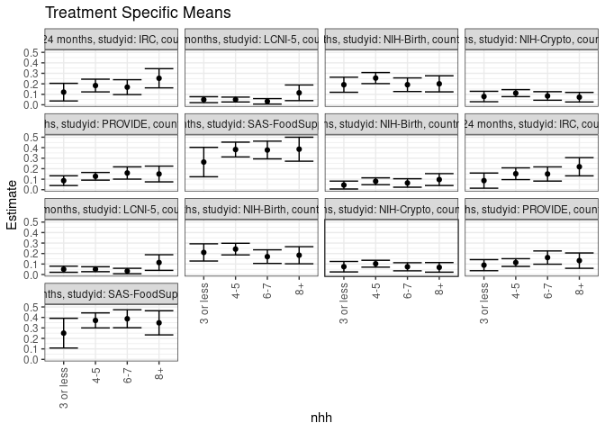

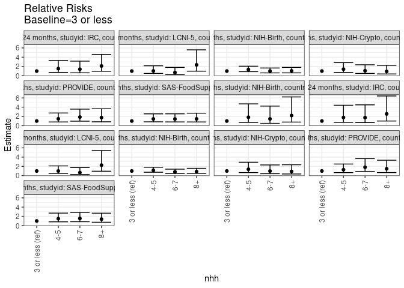

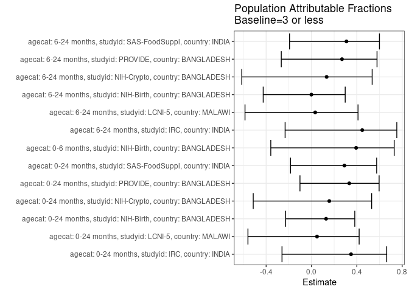

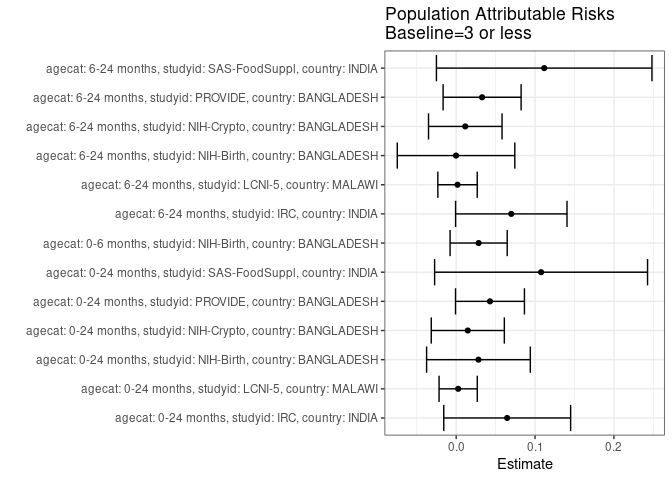

## Results Table

### Parameter: TSM

| agecat | studyid | country | intervention_level | baseline_level | estimate | ci_lower | ci_upper |
| --- | --- | --- | --- | --- | --- | --- | --- |
| 0-24 months | IRC | INDIA | 3 or less | NA | 0.1206897 | 0.0367494 | 0.2046299 |
| 0-24 months | IRC | INDIA | 4-5 | NA | 0.1835443 | 0.1231096 | 0.2439790 |
| 0-24 months | IRC | INDIA | 6-7 | NA | 0.1682243 | 0.0972610 | 0.2391876 |
| 0-24 months | IRC | INDIA | 8+ | NA | 0.2528736 | 0.1614270 | 0.3443202 |
| 0-24 months | LCNI-5 | MALAWI | 3 or less | NA | 0.0488889 | 0.0206957 | 0.0770820 |
| 0-24 months | LCNI-5 | MALAWI | 4-5 | NA | 0.0500000 | 0.0268196 | 0.0731804 |
| 0-24 months | LCNI-5 | MALAWI | 6-7 | NA | 0.0329670 | 0.0070110 | 0.0589231 |
| 0-24 months | LCNI-5 | MALAWI | 8+ | NA | 0.1142857 | 0.0397082 | 0.1888632 |
| 0-24 months | NIH-Birth | BANGLADESH | 3 or less | NA | 0.1913043 | 0.1193590 | 0.2632496 |
| 0-24 months | NIH-Birth | BANGLADESH | 4-5 | NA | 0.2547529 | 0.2020507 | 0.3074550 |
| 0-24 months | NIH-Birth | BANGLADESH | 6-7 | NA | 0.1914894 | 0.1264911 | 0.2564877 |
| 0-24 months | NIH-Birth | BANGLADESH | 8+ | NA | 0.2000000 | 0.1234295 | 0.2765705 |
| 0-24 months | NIH-Crypto | BANGLADESH | 3 or less | NA | 0.0789474 | 0.0294145 | 0.1284802 |
| 0-24 months | NIH-Crypto | BANGLADESH | 4-5 | NA | 0.1111111 | 0.0777820 | 0.1444403 |
| 0-24 months | NIH-Crypto | BANGLADESH | 6-7 | NA | 0.0842697 | 0.0434336 | 0.1251058 |
| 0-24 months | NIH-Crypto | BANGLADESH | 8+ | NA | 0.0725806 | 0.0268853 | 0.1182760 |
| 0-24 months | PROVIDE | BANGLADESH | 3 or less | NA | 0.0857143 | 0.0393096 | 0.1321190 |
| 0-24 months | PROVIDE | BANGLADESH | 4-5 | NA | 0.1273292 | 0.0908941 | 0.1637643 |
| 0-24 months | PROVIDE | BANGLADESH | 6-7 | NA | 0.1589404 | 0.1005824 | 0.2172984 |
| 0-24 months | PROVIDE | BANGLADESH | 8+ | NA | 0.1494253 | 0.0744588 | 0.2243918 |
| 0-24 months | SAS-FoodSuppl | INDIA | 3 or less | NA | 0.2631579 | 0.1229825 | 0.4033333 |
| 0-24 months | SAS-FoodSuppl | INDIA | 4-5 | NA | 0.3825137 | 0.3120152 | 0.4530122 |
| 0-24 months | SAS-FoodSuppl | INDIA | 6-7 | NA | 0.3779528 | 0.2935228 | 0.4623828 |
| 0-24 months | SAS-FoodSuppl | INDIA | 8+ | NA | 0.3857143 | 0.2715482 | 0.4998804 |
| 0-6 months | NIH-Birth | BANGLADESH | 3 or less | NA | 0.0438596 | 0.0062379 | 0.0814814 |
| 0-6 months | NIH-Birth | BANGLADESH | 4-5 | NA | 0.0798479 | 0.0470625 | 0.1126334 |
| 0-6 months | NIH-Birth | BANGLADESH | 6-7 | NA | 0.0638298 | 0.0234488 | 0.1042108 |
| 0-6 months | NIH-Birth | BANGLADESH | 8+ | NA | 0.0961538 | 0.0394501 | 0.1528575 |
| 6-24 months | IRC | INDIA | 3 or less | NA | 0.0862069 | 0.0138867 | 0.1585270 |
| 6-24 months | IRC | INDIA | 4-5 | NA | 0.1518987 | 0.0958648 | 0.2079326 |
| 6-24 months | IRC | INDIA | 6-7 | NA | 0.1495327 | 0.0818803 | 0.2171851 |
| 6-24 months | IRC | INDIA | 8+ | NA | 0.2183908 | 0.1314686 | 0.3053130 |
| 6-24 months | LCNI-5 | MALAWI | 3 or less | NA | 0.0504587 | 0.0213840 | 0.0795334 |
| 6-24 months | LCNI-5 | MALAWI | 4-5 | NA | 0.0505952 | 0.0271460 | 0.0740445 |
| 6-24 months | LCNI-5 | MALAWI | 6-7 | NA | 0.0331492 | 0.0070519 | 0.0592464 |
| 6-24 months | LCNI-5 | MALAWI | 8+ | NA | 0.1142857 | 0.0397075 | 0.1888639 |
| 6-24 months | NIH-Birth | BANGLADESH | 3 or less | NA | 0.2105263 | 0.1284705 | 0.2925821 |
| 6-24 months | NIH-Birth | BANGLADESH | 4-5 | NA | 0.2424242 | 0.1871091 | 0.2977394 |
| 6-24 months | NIH-Birth | BANGLADESH | 6-7 | NA | 0.1705426 | 0.1055794 | 0.2355059 |
| 6-24 months | NIH-Birth | BANGLADESH | 8+ | NA | 0.1839080 | 0.1024265 | 0.2653896 |
| 6-24 months | NIH-Crypto | BANGLADESH | 3 or less | NA | 0.0747664 | 0.0248971 | 0.1246356 |
| 6-24 months | NIH-Crypto | BANGLADESH | 4-5 | NA | 0.1030303 | 0.0702087 | 0.1358519 |
| 6-24 months | NIH-Crypto | BANGLADESH | 6-7 | NA | 0.0738636 | 0.0351965 | 0.1125308 |
| 6-24 months | NIH-Crypto | BANGLADESH | 8+ | NA | 0.0683761 | 0.0226119 | 0.1141402 |
| 6-24 months | PROVIDE | BANGLADESH | 3 or less | NA | 0.0892857 | 0.0364321 | 0.1421394 |
| 6-24 months | PROVIDE | BANGLADESH | 4-5 | NA | 0.1141869 | 0.0774897 | 0.1508840 |
| 6-24 months | PROVIDE | BANGLADESH | 6-7 | NA | 0.1615385 | 0.0982230 | 0.2248539 |
| 6-24 months | PROVIDE | BANGLADESH | 8+ | NA | 0.1325301 | 0.0595260 | 0.2055343 |
| 6-24 months | SAS-FoodSuppl | INDIA | 3 or less | NA | 0.2500000 | 0.1083751 | 0.3916249 |
| 6-24 months | SAS-FoodSuppl | INDIA | 4-5 | NA | 0.3714286 | 0.2997505 | 0.4431066 |
| 6-24 months | SAS-FoodSuppl | INDIA | 6-7 | NA | 0.3870968 | 0.3012577 | 0.4729359 |
| 6-24 months | SAS-FoodSuppl | INDIA | 8+ | NA | 0.3484848 | 0.2333856 | 0.4635841 |

### Parameter: E(Y)

| agecat | studyid | country | intervention_level | baseline_level | estimate | ci_lower | ci_upper |
| --- | --- | --- | --- | --- | --- | --- | --- |
| 0-24 months | IRC | INDIA | NA | NA | 0.1853659 | 0.1477057 | 0.2230261 |
| 0-24 months | LCNI-5 | MALAWI | NA | NA | 0.0514076 | 0.0362561 | 0.0665591 |
| 0-24 months | NIH-Birth | BANGLADESH | NA | NA | 0.2195513 | 0.1870467 | 0.2520558 |
| 0-24 months | NIH-Crypto | BANGLADESH | NA | NA | 0.0936675 | 0.0729118 | 0.1144233 |
| 0-24 months | PROVIDE | BANGLADESH | NA | NA | 0.1285714 | 0.1037574 | 0.1533855 |
| 0-24 months | SAS-FoodSuppl | INDIA | NA | NA | 0.3708134 | 0.3244530 | 0.4171738 |
| 0-6 months | NIH-Birth | BANGLADESH | NA | NA | 0.0723473 | 0.0519719 | 0.0927227 |
| 6-24 months | IRC | INDIA | NA | NA | 0.1560976 | 0.1209228 | 0.1912723 |
| 6-24 months | LCNI-5 | MALAWI | NA | NA | 0.0521739 | 0.0368026 | 0.0675452 |
| 6-24 months | NIH-Birth | BANGLADESH | NA | NA | 0.2103321 | 0.1759902 | 0.2446740 |
| 6-24 months | NIH-Crypto | BANGLADESH | NA | NA | 0.0863014 | 0.0659171 | 0.1066856 |
| 6-24 months | PROVIDE | BANGLADESH | NA | NA | 0.1221498 | 0.0962275 | 0.1480722 |
| 6-24 months | SAS-FoodSuppl | INDIA | NA | NA | 0.3615960 | 0.3145115 | 0.4086805 |

### Parameter: RR

| agecat | studyid | country | intervention_level | baseline_level | estimate | ci_lower | ci_upper |
| --- | --- | --- | --- | --- | --- | --- | --- |
| 0-24 months | IRC | INDIA | 3 or less | 3 or less | 1.0000000 | 1.0000000 | 1.000000 |
| 0-24 months | IRC | INDIA | 4-5 | 3 or less | 1.5207957 | 0.7044945 | 3.282949 |
| 0-24 months | IRC | INDIA | 6-7 | 3 or less | 1.3938585 | 0.6179437 | 3.144043 |
| 0-24 months | IRC | INDIA | 8+ | 3 or less | 2.0952381 | 0.9567285 | 4.588577 |
| 0-24 months | LCNI-5 | MALAWI | 3 or less | 3 or less | 1.0000000 | 1.0000000 | 1.000000 |
| 0-24 months | LCNI-5 | MALAWI | 4-5 | 3 or less | 1.0227273 | 0.4879936 | 2.143412 |
| 0-24 months | LCNI-5 | MALAWI | 6-7 | 3 or less | 0.6743257 | 0.2541124 | 1.789425 |
| 0-24 months | LCNI-5 | MALAWI | 8+ | 3 or less | 2.3376623 | 0.9785333 | 5.584547 |
| 0-24 months | NIH-Birth | BANGLADESH | 3 or less | 3 or less | 1.0000000 | 1.0000000 | 1.000000 |
| 0-24 months | NIH-Birth | BANGLADESH | 4-5 | 3 or less | 1.3316626 | 0.8669325 | 2.045517 |
| 0-24 months | NIH-Birth | BANGLADESH | 6-7 | 3 or less | 1.0009671 | 0.6031191 | 1.661256 |
| 0-24 months | NIH-Birth | BANGLADESH | 8+ | 3 or less | 1.0454545 | 0.6112713 | 1.788036 |
| 0-24 months | NIH-Crypto | BANGLADESH | 3 or less | 3 or less | 1.0000000 | 1.0000000 | 1.000000 |
| 0-24 months | NIH-Crypto | BANGLADESH | 4-5 | 3 or less | 1.4074074 | 0.7020963 | 2.821259 |
| 0-24 months | NIH-Crypto | BANGLADESH | 6-7 | 3 or less | 1.0674157 | 0.4831033 | 2.358453 |
| 0-24 months | NIH-Crypto | BANGLADESH | 8+ | 3 or less | 0.9193548 | 0.3779794 | 2.236136 |
| 0-24 months | PROVIDE | BANGLADESH | 3 or less | 3 or less | 1.0000000 | 1.0000000 | 1.000000 |
| 0-24 months | PROVIDE | BANGLADESH | 4-5 | 3 or less | 1.4855072 | 0.8052506 | 2.740429 |
| 0-24 months | PROVIDE | BANGLADESH | 6-7 | 3 or less | 1.8543046 | 0.9640212 | 3.566774 |
| 0-24 months | PROVIDE | BANGLADESH | 8+ | 3 or less | 1.7432950 | 0.8333257 | 3.646926 |
| 0-24 months | SAS-FoodSuppl | INDIA | 3 or less | 3 or less | 1.0000000 | 1.0000000 | 1.000000 |
| 0-24 months | SAS-FoodSuppl | INDIA | 4-5 | 3 or less | 1.4535519 | 0.8272570 | 2.553998 |
| 0-24 months | SAS-FoodSuppl | INDIA | 6-7 | 3 or less | 1.4362205 | 0.8060600 | 2.559027 |
| 0-24 months | SAS-FoodSuppl | INDIA | 8+ | 3 or less | 1.4657143 | 0.7968927 | 2.695869 |
| 0-6 months | NIH-Birth | BANGLADESH | 3 or less | 3 or less | 1.0000000 | 1.0000000 | 1.000000 |
| 0-6 months | NIH-Birth | BANGLADESH | 4-5 | 3 or less | 1.8205323 | 0.7033826 | 4.711998 |
| 0-6 months | NIH-Birth | BANGLADESH | 6-7 | 3 or less | 1.4553191 | 0.5012700 | 4.225176 |
| 0-6 months | NIH-Birth | BANGLADESH | 8+ | 3 or less | 2.1923077 | 0.7741573 | 6.208316 |
| 6-24 months | IRC | INDIA | 3 or less | 3 or less | 1.0000000 | 1.0000000 | 1.000000 |
| 6-24 months | IRC | INDIA | 4-5 | 3 or less | 1.7620253 | 0.7047074 | 4.405706 |
| 6-24 months | IRC | INDIA | 6-7 | 3 or less | 1.7345794 | 0.6687337 | 4.499199 |
| 6-24 months | IRC | INDIA | 8+ | 3 or less | 2.5333333 | 1.0009946 | 6.411401 |
| 6-24 months | LCNI-5 | MALAWI | 3 or less | 3 or less | 1.0000000 | 1.0000000 | 1.000000 |
| 6-24 months | LCNI-5 | MALAWI | 4-5 | 3 or less | 1.0027056 | 0.4786582 | 2.100494 |
| 6-24 months | LCNI-5 | MALAWI | 6-7 | 3 or less | 0.6569563 | 0.2476491 | 1.742754 |
| 6-24 months | LCNI-5 | MALAWI | 8+ | 3 or less | 2.2649351 | 0.9483814 | 5.409143 |
| 6-24 months | NIH-Birth | BANGLADESH | 3 or less | 3 or less | 1.0000000 | 1.0000000 | 1.000000 |
| 6-24 months | NIH-Birth | BANGLADESH | 4-5 | 3 or less | 1.1515152 | 0.7330337 | 1.808903 |
| 6-24 months | NIH-Birth | BANGLADESH | 6-7 | 3 or less | 0.8100775 | 0.4697200 | 1.397057 |
| 6-24 months | NIH-Birth | BANGLADESH | 8+ | 3 or less | 0.8735632 | 0.4841925 | 1.576052 |
| 6-24 months | NIH-Crypto | BANGLADESH | 3 or less | 3 or less | 1.0000000 | 1.0000000 | 1.000000 |
| 6-24 months | NIH-Crypto | BANGLADESH | 4-5 | 3 or less | 1.3780303 | 0.6580232 | 2.885867 |
| 6-24 months | NIH-Crypto | BANGLADESH | 6-7 | 3 or less | 0.9879261 | 0.4231416 | 2.306552 |
| 6-24 months | NIH-Crypto | BANGLADESH | 8+ | 3 or less | 0.9145299 | 0.3554914 | 2.352701 |
| 6-24 months | PROVIDE | BANGLADESH | 3 or less | 3 or less | 1.0000000 | 1.0000000 | 1.000000 |
| 6-24 months | PROVIDE | BANGLADESH | 4-5 | 3 or less | 1.2788927 | 0.6520858 | 2.508208 |
| 6-24 months | PROVIDE | BANGLADESH | 6-7 | 3 or less | 1.8092308 | 0.8895323 | 3.679817 |
| 6-24 months | PROVIDE | BANGLADESH | 8+ | 3 or less | 1.4843373 | 0.6612368 | 3.332025 |
| 6-24 months | SAS-FoodSuppl | INDIA | 3 or less | 3 or less | 1.0000000 | 1.0000000 | 1.000000 |
| 6-24 months | SAS-FoodSuppl | INDIA | 4-5 | 3 or less | 1.4857143 | 0.8166281 | 2.703001 |
| 6-24 months | SAS-FoodSuppl | INDIA | 6-7 | 3 or less | 1.5483871 | 0.8427029 | 2.845015 |
| 6-24 months | SAS-FoodSuppl | INDIA | 8+ | 3 or less | 1.3939394 | 0.7235269 | 2.685549 |

### Parameter: PAR

| agecat | studyid | country | intervention_level | baseline_level | estimate | ci_lower | ci_upper |
| --- | --- | --- | --- | --- | --- | --- | --- |
| 0-24 months | IRC | INDIA | 3 or less | NA | 0.0646762 | -0.0157649 | 0.1451173 |
| 0-24 months | LCNI-5 | MALAWI | 3 or less | NA | 0.0025187 | -0.0217015 | 0.0267389 |
| 0-24 months | NIH-Birth | BANGLADESH | 3 or less | NA | 0.0282469 | -0.0375163 | 0.0940102 |
| 0-24 months | NIH-Crypto | BANGLADESH | 3 or less | NA | 0.0147202 | -0.0316081 | 0.0610485 |
| 0-24 months | PROVIDE | BANGLADESH | 3 or less | NA | 0.0428571 | -0.0008209 | 0.0865352 |
| 0-24 months | SAS-FoodSuppl | INDIA | 3 or less | NA | 0.1076555 | -0.0273477 | 0.2426587 |
| 0-6 months | NIH-Birth | BANGLADESH | 3 or less | NA | 0.0284876 | -0.0077301 | 0.0647053 |
| 6-24 months | IRC | INDIA | 3 or less | NA | 0.0698907 | -0.0007330 | 0.1405143 |
| 6-24 months | LCNI-5 | MALAWI | 3 or less | NA | 0.0017152 | -0.0232601 | 0.0266905 |
| 6-24 months | NIH-Birth | BANGLADESH | 3 or less | NA | -0.0001942 | -0.0747072 | 0.0743188 |
| 6-24 months | NIH-Crypto | BANGLADESH | 3 or less | NA | 0.0115350 | -0.0350848 | 0.0581549 |
| 6-24 months | PROVIDE | BANGLADESH | 3 or less | NA | 0.0328641 | -0.0165964 | 0.0823247 |
| 6-24 months | SAS-FoodSuppl | INDIA | 3 or less | NA | 0.1115960 | -0.0250539 | 0.2482459 |

### Parameter: PAF

| agecat | studyid | country | intervention_level | baseline_level | estimate | ci_lower | ci_upper |
| --- | --- | --- | --- | --- | --- | --- | --- |
| 0-24 months | IRC | INDIA | 3 or less | NA | 0.3489111 | -0.2600050 | 0.6635594 |
| 0-24 months | LCNI-5 | MALAWI | 3 or less | NA | 0.0489947 | -0.5604430 | 0.4204139 |
| 0-24 months | NIH-Birth | BANGLADESH | 3 or less | NA | 0.1286576 | -0.2283696 | 0.3819143 |
| 0-24 months | NIH-Crypto | BANGLADESH | 3 or less | NA | 0.1571534 | -0.5138446 | 0.5307376 |
| 0-24 months | PROVIDE | BANGLADESH | 3 or less | NA | 0.3333333 | -0.1015512 | 0.5965286 |
| 0-24 months | SAS-FoodSuppl | INDIA | 3 or less | NA | 0.2903226 | -0.1848905 | 0.5749463 |
| 0-6 months | NIH-Birth | BANGLADESH | 3 or less | NA | 0.3937622 | -0.3589707 | 0.7295569 |
| 6-24 months | IRC | INDIA | 3 or less | NA | 0.4477371 | -0.2326072 | 0.7525616 |
| 6-24 months | LCNI-5 | MALAWI | 3 or less | NA | 0.0328746 | -0.5863693 | 0.4103948 |
| 6-24 months | NIH-Birth | BANGLADESH | 3 or less | NA | -0.0009234 | -0.4259807 | 0.2974326 |
| 6-24 months | NIH-Crypto | BANGLADESH | 3 or less | NA | 0.1336597 | -0.6147363 | 0.5351900 |
| 6-24 months | PROVIDE | BANGLADESH | 3 or less | NA | 0.2690476 | -0.2663603 | 0.5780890 |
| 6-24 months | SAS-FoodSuppl | INDIA | 3 or less | NA | 0.3086207 | -0.1934670 | 0.5994817 |